# Sparse partial least-squares regression analysis

Defeng Bai Agricultural Genomics Institute at Shenzhen, Chinese Academy of Agricultural Sciences

2024-08-05

### sPLS analysis

什么是sPLS？ What is sPLS? sPLS, Sparse partial least-squares regression, 稀疏偏最小二乘回归

最小二乘法，又称最小平方法，是一种数学优化建模方法。它通过最小化误差的平方和寻找数据的最佳函数匹配。利用最小二乘法可以简便的求得未知的数据，并使得求得的数据与实际数据之间误差的平方和为最小。偏最小二乘（PLS）最大化潜在变量之间的协方差，而不是相关性，它能够同时对多个响应变量进行建模，并处理嘈杂的相关变量，但在对高维数据进行操作时，其可解释性受到影响。sPLS(稀疏偏最小二乘法)在PLS的基础上，综合运用PCA,CCA和LASSO三种模型，将高维数据降维，提取主成分，开展相关性分析，使用LASSO罚分测虐挑选出核心元素，最终输出样本分布图和两组学强相关的元素集合，最后通过相关性散点图呈现关键物种和代谢物。稀疏偏最小二乘回归方法在PLS中内置了变量选择过程，并且在融合两组组学和对结果的生物学解释方面有良好的性能。也就是将lasso惩罚变量选择法加入了PLS。

The least squares method, also known as the least squares method, is a mathematical optimization modeling method. It finds the best function match for the data by minimizing the sum of squared errors. The use of the least squares method can easily obtain unknown data and minimize the sum of squared errors between the obtained data and the actual data. Partial Least Squares (PLS) maximize the covariance between latent variables, rather than correlation. It can model multiple response variables simultaneously and handle noisy correlated variables, but its interpretability is affected when operating on high-dimensional data. SPLS (Sparse Partial Least Squares) combines PCA, CCA, and LASSO models on the basis of PLS to reduce the dimensionality of high-dimensional data, extract principal components, conduct correlation analysis, use LASSO penalty score to select core elements, and finally output a sample distribution map and a set of strongly correlated elements between two omics. Finally, key species and metabolites are presented through a correlation scatter plot. The sparse partial least squares regression method has a built-in variable selection process in PLS and performs well in integrating two omics and biological interpretation of the results. That is to say, the Lasso penalty variable selection method was added to PLS.

### sPLS分析案例

SPLS analysis case

这是Jakob Stokholm课题组2023年发表于Nature Medicine上的文章，第一作者为Cristina Leal Rodríguez，题目为：The infant gut virome is associated with preschool asthma risk independently of bacteria

This is an article published by the Jakob Stokholm research group in Nature Medicine in 2023. The first author is Cristina Leal Rodr í guez, and the title is: The incident gut virus is associated with pre-school astroma risk independently of bacteria

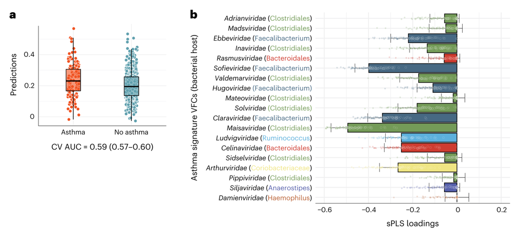

Fig. 3 a, AUC from repeated tenfold cross-validation (CV) of an sPLS model for core temperate VFCs at 1 year of age and preschool asthma (n = 133 out of 498). The box plots represent the class predictions for the median cross-validated model. The center of the boxes represents the median, their bounds represent the 25th and 75th percentiles and the lower and upper ends of whiskers represent the smallest and largest values, respectively, no further than 1.5 × IQR from the respective end of the box plot. b, Representation of the 19 signature VFCs (all caudoviruses) contributing to the optimal set of loadings for the ten-times repeated tenfold cross-validation sPLS model (n = 100) using the entire cohort (n = 631). Bars depict the median across repeats ± s.d. VFCs are sorted from top to bottom based on their mean relative abundance (higher to lower) and colored by their most frequent host (predicted by sequence similarity). All VFCs presented negative loadings, implying that they were present at lower abundances in the relative space of the core temperate virome in the infant gut of children later developing asthma compared to controls (n = 133 out of 498).

图3 a，1岁时核心温带VFCs和学龄前哮喘的sPLS模型的重复十倍交叉验证（CV）的AUC（498个中n=133）。方框图表示中值交叉验证模型的类别预测。方框的中心表示中值，其边界表示第25个和第75个百分位数，胡须的下端和上端分别表示最小值和最大值，距离方框图的各个端部不超过1.5×IQR。b、使用整个队列（n=631），对十次重复十倍交叉验证的sPLS模型（n=100）的最佳载荷集做出贡献的19个特征VFC（所有caudoviruse）的表示。条形图描绘了重复±s.d.之间的中位数。VFC根据其平均相对丰度（从高到低）从上到下排序，并按其最频繁的宿主着色（通过序列相似性预测）。所有VFCs均呈负负荷，这意味着与对照组相比，它们在后来发展为哮喘的儿童的婴儿肠道中核心温带病毒组的相对空间中的丰度较低（498个中n=133）。

**结果**： As the compositional differences were observed primarily in the temperate virome, we then aimed to identify the smallest possible set of covariant core temperate phage families that were associated with the development of asthma, and computed a virome asthma signature score for each child. This was achieved by a repeated tenfold cross-validated sparse partial least squares (sPLS) model, which accomplished adequate performance with a cross-validated median repeat area under the curve (AUC) of 0.59 (0.57–0.60) (Fig. 3a). The model selected a minimal set of 19 temperate VFCs that were jointly associated with later asthma (Fig. 3b). An increase of one standard deviation in the virome asthma score corresponded to a 34% increase in the odds of developing asthma by 5 years of age (OR = 1.34 (1.11–1.62); P = 0.002).

由于主要在温带病毒组中观察到成分差异，因此我们旨在确定与哮喘发展相关的尽可能小的协变核心温和噬菌体科，并计算每个儿童的病毒组哮喘特征得分。这是通过重复的十倍交叉验证的稀疏偏最小二乘（sPLS）模型实现的，该模型实现了足够的性能，交叉验证的曲线下重复面积中位数（AUC）为0.59（0.57–0.60）（图第3a段）。该模型选择了一组最小的19个与后期哮喘共同相关的温带VFC（图第3b段）。病毒性哮喘评分增加一个标准差，5岁时患哮喘的几率增加34%（OR=1.34（1.11-1.62）；P＝0.002）。

### sPLS分析实战

SPLS analysis in practice

参考：https://cloud.tencent.com/developer/article/1652738

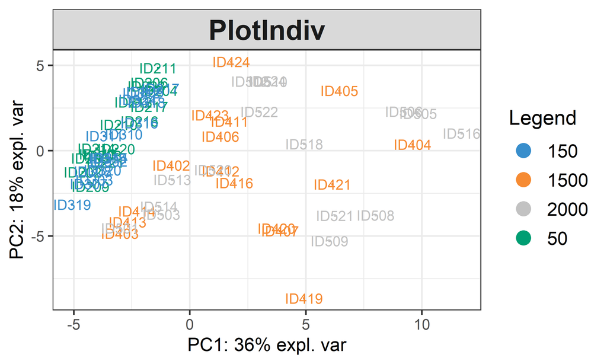

```r
# BiocManager::install("mixOmics")
library(mixOmics)

# 1. PCA分析，主要是以线性方式结合多个独立变量进行降维分析
# 1. PCA analysis, mainly combining multiple independent variables in a linear manner for dimensionality reduction analysis
data(liver.toxicity)
X <- liver.toxicity$gene
MyResult.pca <- pca(X)
plotIndiv(MyResult.pca, group = liver.toxicity$treatment$Dose.Group, legend = TRUE)
```

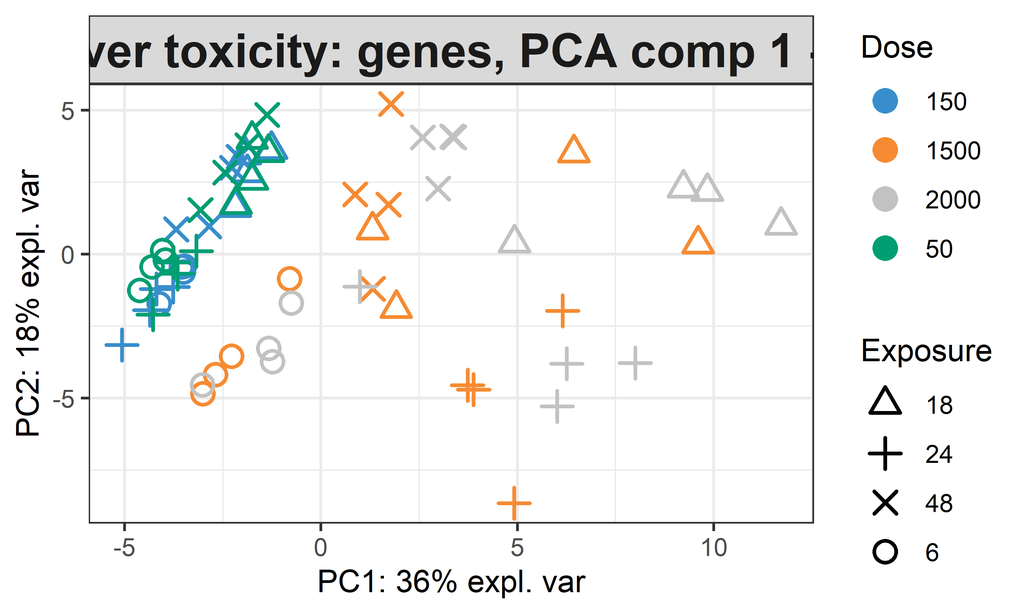

```r
plotIndiv(MyResult.pca, ind.names = FALSE,
          group = liver.toxicity$treatment$Dose.Group,
          pch = as.factor(liver.toxicity$treatment$Time.Group),
          legend = TRUE, title = 'Liver toxicity: genes, PCA comp 1 - 2',
          legend.title = 'Dose', legend.title.pch = 'Exposure')
```

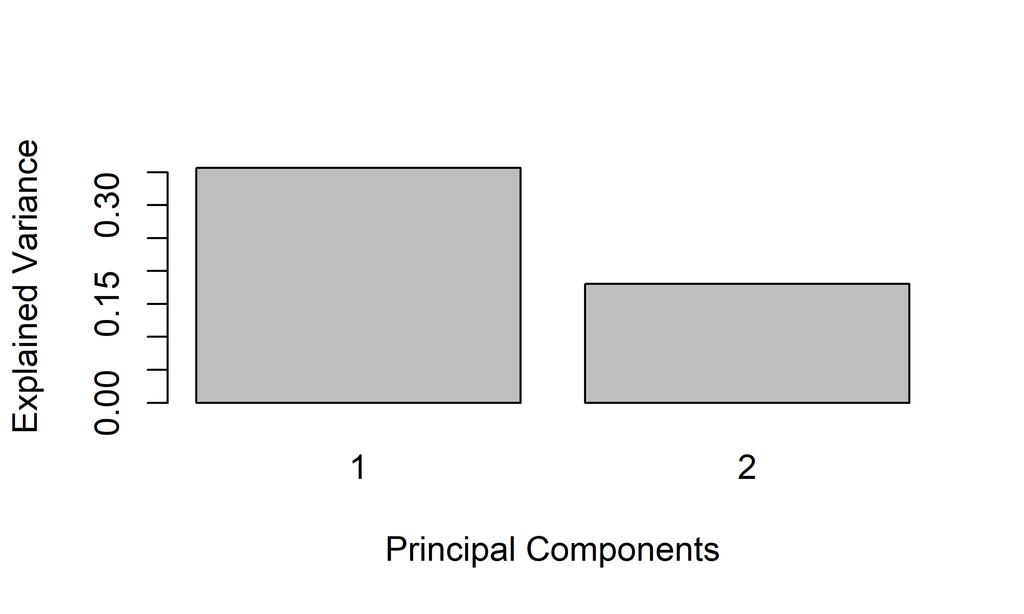

```r
plot(MyResult.pca)
```

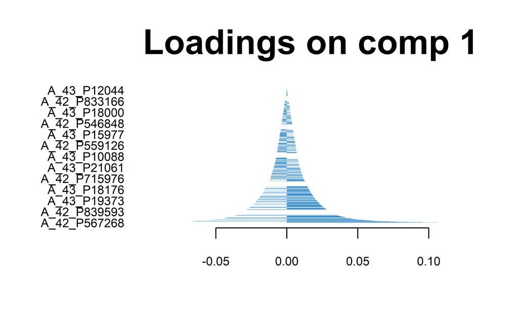

```r
plotLoadings(MyResult.pca)
```

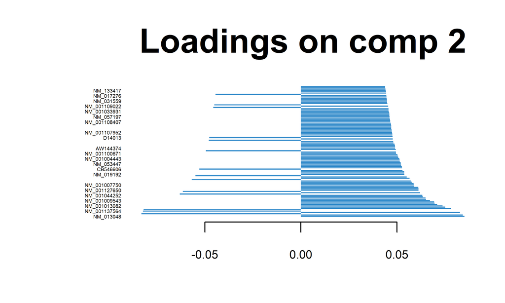

```r
# 从这个图可以看到每个变量对每个组间的贡献，将其展示在一个柱状图中，其中每个柱状图长度对应于样本对组间的装载量（重要性）。装载量可以是正的，也可以是负数。
# From this graph, we can see the contribution of each variable to each group, which is displayed in a bar graph where the length of each bar corresponds to the loading (importance) of the sample between groups. The loading capacity can be either positive or negative.

plotLoadings(MyResult.pca, ndisplay = 100, comp = 2,
             name.var = liver.toxicity$gene.ID[, "geneBank"],
             size.name = rel(0.3))
```

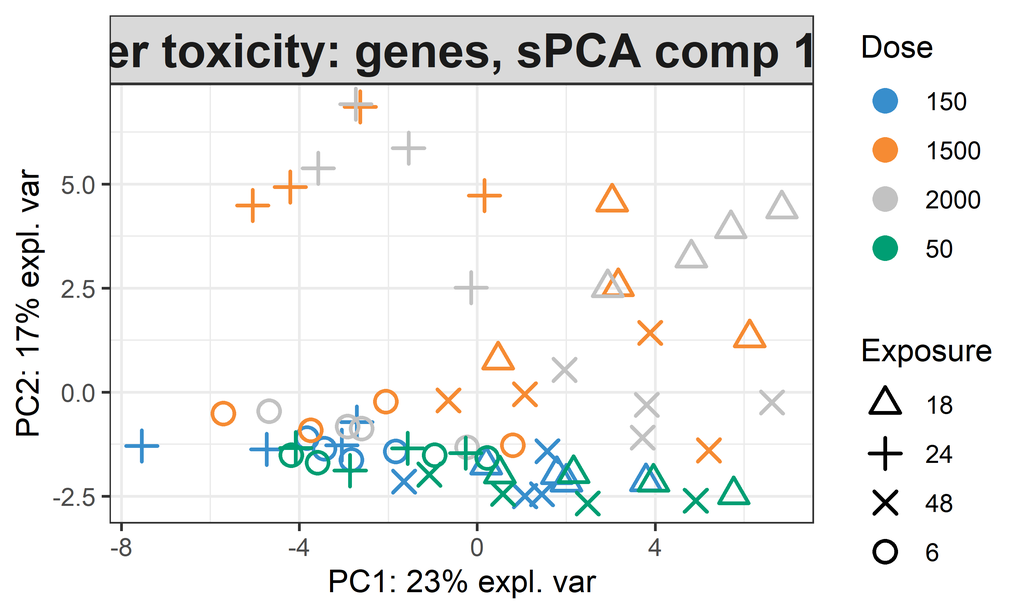

```r
# 从3D角度来看PCA的分析结果
# From a 3D perspective, the analysis results of PCA
MyResult.pca2 <- pca(X, ncomp = 3)
plotIndiv(MyResult.pca2,
          group = liver.toxicity$treatment$Dose.Group, style = "3d",
          legend = TRUE, title = 'Liver toxicity: genes, PCA comp 1 - 2 - 3')

# 2. 稀疏矩阵PCA分析，此函数相对于PCA多了keepX参数可以设置在每个组间起作用的前几个基因或者样本
# 2. Sparse matrix PCA analysis, this function has an additional keepX parameter compared to PCA, which can be set to the top few genes or samples that work between each group
MyResult.spca <- spca(X, ncomp = 3, keepX = c(15, 10, 5))
plotIndiv(MyResult.spca, group = liver.toxicity$treatment$Dose.Group,
          pch = as.factor(liver.toxicity$treatment$Time.Group),
          legend = TRUE, title = 'Liver toxicity: genes, sPCA comp 1 - 2',
          legend.title = 'Dose', legend.title.pch = 'Exposure')
```

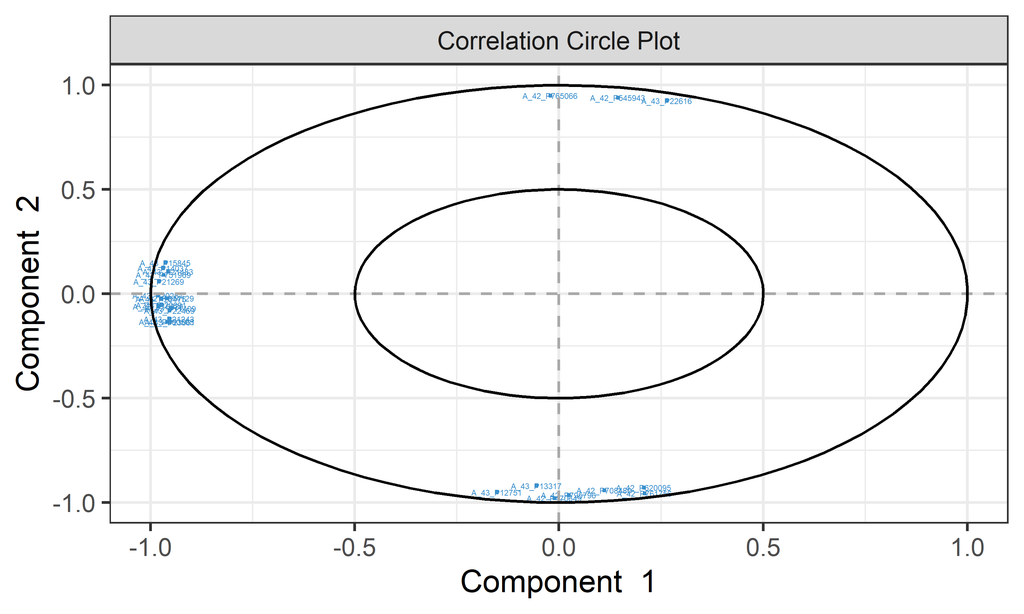

```r
plotVar(MyResult.spca, cex = 1)
```

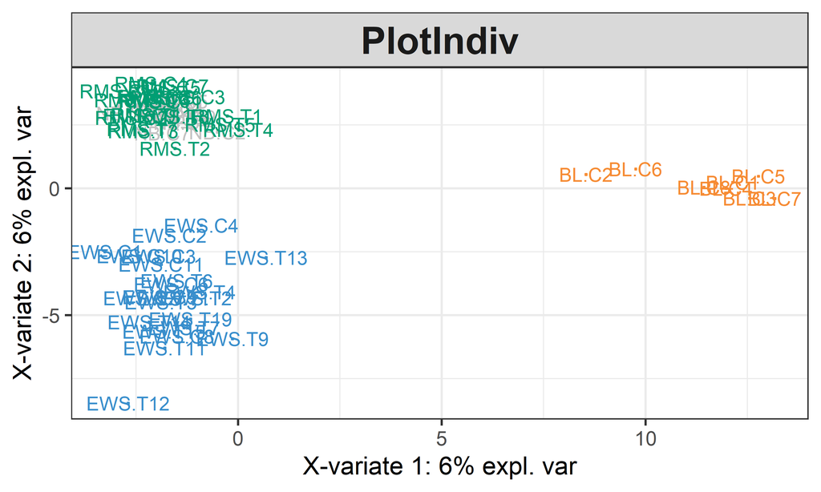

```r
# 这个图是极坐标图，主要体现各变量之间的相关性分布。
# This graph is a polar coordinate graph, mainly reflecting the correlation distribution between variables.

# 在PCA还可以直接看下explained variance score(主要体现自变量对因变量的贡献度，介于0-1之间，值越大代表贡献越大)，需要用到函数tune.pca(X)
# In PCA, you can also directly look at the explained variance score (which mainly reflects the contribution of the independent variable to the dependent variable, ranging from 0 to 1, with larger values indicating greater contribution), which requires the use of the function tune.pca(X)

# 3. PLS-DA分析，虽然偏最小二乘法最初没有应用于分类和辨别问题。后来经过改造还是被用来进行分类研究。
# 3. PLS-DA analysis, although partial least squares method was not initially applied to classification and discrimination problems. Later, after renovation, it was still used for classification research.
data(srbct)
X <- srbct$gene
Y <- srbct$class
MyResult.splsda <- splsda(X, Y, keepX = c(50, 50))
plotIndiv(MyResult.splsda)
```

```r
selectVar(MyResult.splsda, comp = 1)$value  # 查看组件1中涉及的变量名称值。
```

```
         value.var
g123  0.3043756455
g846  0.2678549830
g758  0.2372146849
g836  0.2360362880
g1606 0.2350958099
g335  0.2334438975
g783  0.2228936068
g1386 0.2198879265
g1884 0.1997582765
g585  0.1889851884
g589  0.1883927246
g1158 0.1881272859
g1387 0.1864010811
g165  0.1657260773
g1036 0.1583276528
g1295 0.1559488517
g1375 0.1456341968
g1116 0.1453436916
g1916 0.1440534219
g74   0.1379508631
g85   0.1347253446
g1099 0.1328584431
g1974 0.1254117907
g998  0.1190700120
g1067 0.1147680418
g1839 0.1080340846
g1915 0.1074358714
g1453 0.1066081232
g1536 0.1012481015
g1279 0.1011903828
g1735 0.0763883304
g555  0.0642430245
g276  0.0636022693
g780  0.0635459168
g188  0.0613738611
g2186 0.0602252536
g190  0.0575156057
g1443 0.0545231071
g2127 0.0457915390
g1090 0.0436282157
g1587 0.0427754550
g166  0.0405184976
g1283 0.0299034833
g1206 0.0247768433
g2279 0.0197767540
g2116 0.0176665758
g2230 0.0151457683
g1008 0.0038713893
g849  0.0034712422
g1042 0.0009304968
```

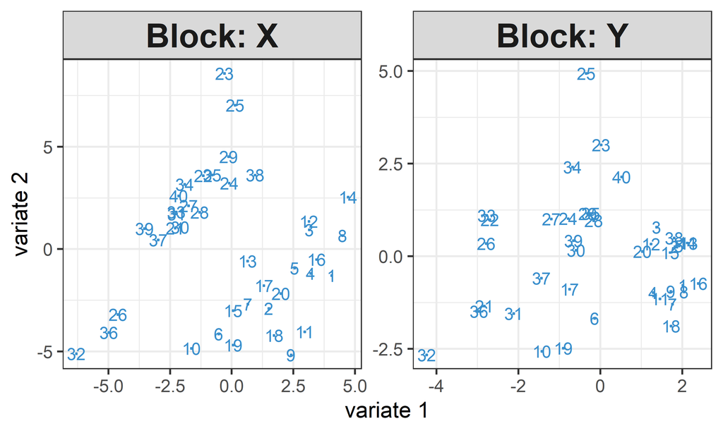

```r
# View the variable names involved in component 1.

# 4. PLS分析，偏最小二乘回归是一种多元方法，它设计两个数据矩阵X和Y。通过对两个矩阵的结构建模，PLS超越了传统的多重回归。与传统的多元回归模型不同，它不局限于不相关的变量。PLS的优点之一是它可以处理许多有噪声的、共线性和缺失变量，还可以同时在Y中建模几个响应变量。
# 4. PLS analysis, partial least squares regression is a multivariate method that designs two data matrices X and Y. By modeling the structure of two matrices, PLS goes beyond traditional multiple regression. Unlike traditional multiple regression models, it is not limited to unrelated variables. One of the advantages of PLS is that it can handle many noisy, collinear, and missing variables, and can also model several response variables simultaneously in Y.
data(nutrimouse)
X <- nutrimouse$gene
Y <- nutrimouse$lipid
MyResult.spls <- spls(X, Y, keepX = c(25, 25), keepY = c(5, 5))
plotIndiv(MyResult.spls)
```

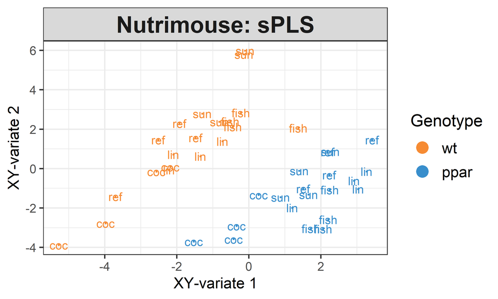

```r
plotIndiv(MyResult.spls, group = nutrimouse$genotype,
          rep.space = "XY-variate", legend = TRUE,
          legend.title = 'Genotype',
          ind.names = nutrimouse$diet,
          title = 'Nutrimouse: sPLS')
```